# Building the Past

- Show All Code
- Hide All Code
- View Source

Author

Austin Mangelson

Between 2007 and 2010, the United States faced one of the [most severe housing market collapses](https://en.wikipedia.org/wiki/Subprime_mortgage_crisis) in its history. The ripple effects of the mortgage crisis led to a dramatic downturn in residential construction activities, profoundly impacting single-family housing permits across the nation.

In this report, we’ll be focusing on single-family housing permits in1980 and in 2010.

A nationwide decrease in single-family home permit values can be a signal for many things, including economic slowdown or recession, affordability issues, and a shifting market.

## Across the U.S.

**Plot**

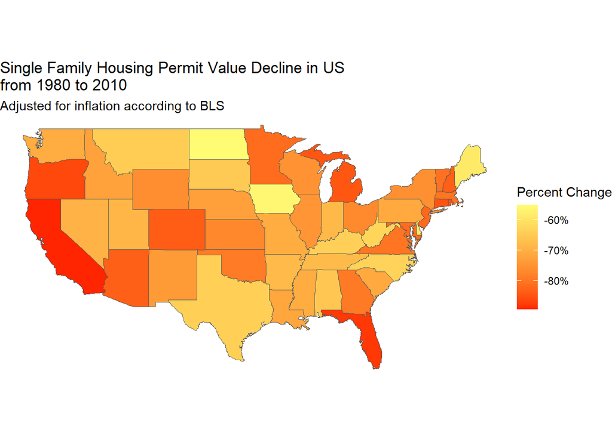

```r
us_permit_values_adj <- merged_us_data |>
  mutate(StateName = str_to_title(StateName)) |>
  rename(name = "StateName") |>
  select(!StateAbbr, !CntyName) |>
  group_by(name, year, FIPS.state) |>
  summarise(total_value = sum(value, na.rm = TRUE)) |>
  filter(year %in% c("1980", "2010")) |>
  pivot_wider(names_from = year, values_from = total_value) |>
  mutate(`1980_adj` = (`1980` * 2.785),
         amnt_change = ((`2010` - `1980_adj`) / `1980_adj`)) |>
  left_join(states, by = "name") |>
  na.omit() |>
  rename(geometry = "geom")

ggplot() +
  geom_sf(data = us_permit_values_adj, aes(geometry = geometry, fill = amnt_change)) +
  scale_fill_gradient(low = "#FF2500", high = "#FFFC74", labels = scales::percent_format()) +
  theme_void() +
  labs(
    title = "Single Family Housing Permit Value Decline in US \nfrom 1980 to 2010",
    subtitle = "Adjusted for inflation according to BLS",
    fill = "Percent Change"
  ) +
  coord_sf(crs = "NAD27")
```

**Data**

```r
datatable(us_permit_values_adj)
```

|  | name | FIPS.state | 1980 | 2010 | 1980_adj | amnt_change | geometry |
| --- | --- | --- | --- | --- | --- | --- | --- |
| 1 | Alabama | 1 | 9040 | 8715 | 25176.4 | -0.6538424874088432 | {'type': 'MultiPolygon', 'coordinates': [[[[-87.46200561523438, 30.38968086242676], [-87.48493194580078, 30.37249183654785], [-87.52503204345703, 30.37249183654785], [-87.53076171875, 30.3323860168457… |
| 2 | Arizona | 4 | 22919 | 10752 | 63829.415 | -0.8315510176616847 | {'type': 'MultiPolygon', 'coordinates': [[[[-114.6373901367188, 35.01918029785156], [-114.6431274414062, 35.10512161254883], [-114.6030197143555, 35.12231063842773], [-114.5743637084961, 35.1796112060… |
| 3 | Arkansas | 5 | 5214 | 4648 | 14520.99 | -0.6799116313694865 | {'type': 'MultiPolygon', 'coordinates': [[[[-94.051025390625, 33.03674697875977], [-94.051025390625, 33.30030822753906], [-94.05675506591797, 33.5753288269043], [-94.07966613769531, 33.58678436279297]… |
| 4 | California | 6 | 86707 | 25693 | 241478.995 | -0.8936015118002293 | {'type': 'MultiPolygon', 'coordinates': [[[[-120.0060119628906, 42.0092658996582], [-120.0060119628906, 41.20139312744141], [-120.0060119628906, 39.70024490356445], [-119.9945526123047, 39.44241333007… |
| 5 | Colorado | 8 | 19319 | 8790 | 53803.415 | -0.8366274705797021 | {'type': 'MultiPolygon', 'coordinates': [[[[-102.0552444458008, 40.0096435546875], [-102.0609664916992, 40.00391387939453], [-102.0552444458008, 39.57992553710938], [-102.0552444458008, 39.56846237182… |
| 6 | Connecticut | 9 | 6211 | 2632 | 17297.635 | -0.8478404706770608 | {'type': 'MultiPolygon', 'coordinates': [[[[-73.4990234375, 42.04937362670898], [-73.04065704345703, 42.04364395141602], [-73.01200866699219, 42.04364395141602], [-72.81720733642578, 42.03791046142578… |
| 7 | Delaware | 10 | 2351 | 2673 | 6547.535000000001 | -0.5917547596156416 | {'type': 'MultiPolygon', 'coordinates': [[[[-75.80231475830078, 39.7288932800293], [-75.76220703125, 39.7288932800293], [-75.74502563476562, 39.75754165649414], [-75.73355865478516, 39.78046035766602]… |
| 8 | District Of Columbia | 11 | 478 | 177 | 1331.23 | -0.867040256003846 | {'type': 'MultiPolygon', 'coordinates': [[[[-77.1373062133789, 38.94394302368164], [-77.06282806396484, 38.99550628662109], [-77.0169906616211, 38.97258758544922], [-76.93104553222656, 38.892375946044… |
| 9 | Florida | 12 | 88957 | 30040 | 247745.245 | -0.878746411459885 | {'type': 'MultiPolygon', 'coordinates': [[[[-85.0154800415039, 30.99701690673828], [-84.998291015625, 30.9626407623291], [-84.97537231445312, 30.92253112792969], [-84.94672393798828, 30.89961624145508… |
| 10 | Georgia | 13 | 25759 | 14872 | 71738.815 | -0.7926924218081941 | {'type': 'MultiPolygon', 'coordinates': [[[[-80.89018249511719, 32.03979873657227], [-80.8500747680664, 32.02834320068359], [-80.84434509277344, 32.01688003540039], [-80.8500747680664, 31.993961334228… |

[output cut: 40 more lines]

As shown above, the value of single-family housing permits declined significantly in 2010 as compared to 1980, with states like California, Florida, Oregon, Rhode Island, and Connecticut seeing over an 80% decrease in permit values.

## Looking at Idaho

Idaho, like many other states, experienced a noticeable decrease in new home construction permit values. This drop reflects the broader economic troubles of the time, where obtaining loans became harder, and fewer new homes were being built.

**Plot**

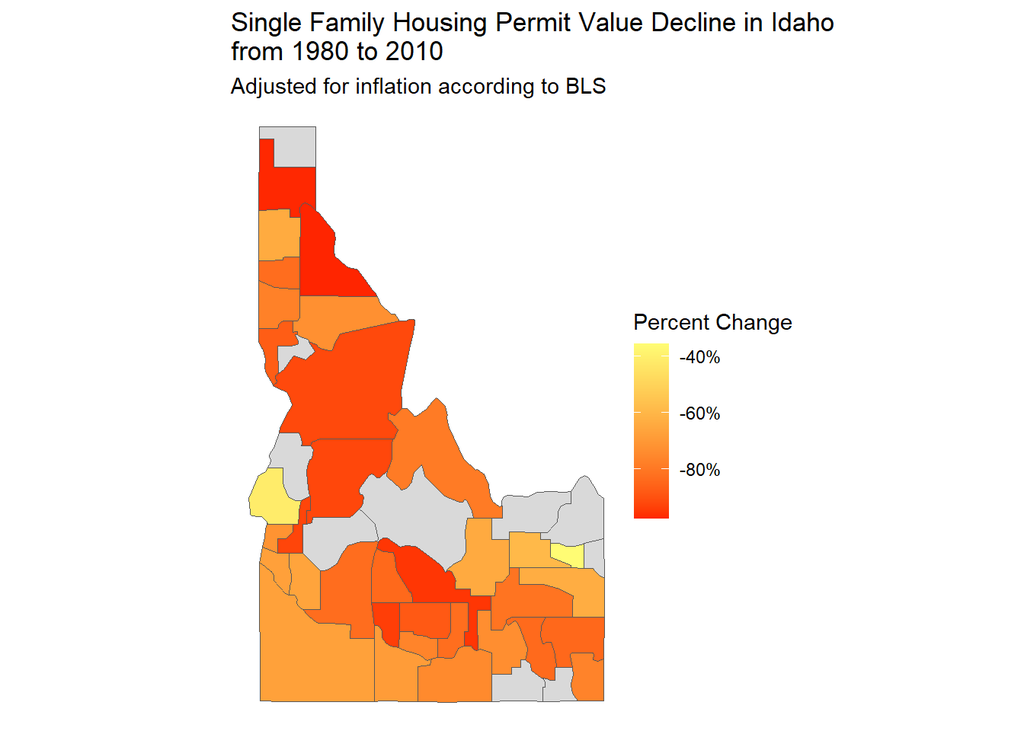

```r
id_permit_values_adj <- merged_id_data |>
  mutate(StateName = str_to_title(StateName)) |>
  rename(name = "StateName") |>
  select(!StateAbbr, !CntyName) |>
  group_by(countyname, year, FIPS.state) |>
  summarise(total_value = sum(value, na.rm = TRUE)) |>
  filter(year %in% c("1980", "2010")) |>
  pivot_wider(names_from = year, values_from = total_value) |>
  mutate(`1980_adj` = (`1980` * 2.785),
         percent_change = ((`2010` - `1980_adj`) / `1980_adj`)) |>
  rename(CntyName = "countyname") |>
  left_join(id_county_data, by = "CntyName") |>
  select(-FIPS.state.x, -FIPS.state.y, -StateName) |>
  mutate(percent_change = if_else(percent_change > 0, NA_real_, percent_change)) |>
  mutate(CntyName = str_sub(CntyName, 1, -8))

ggplot() +
  geom_sf(data = id_permit_values_adj, aes(geometry = geometry, fill = percent_change)) +
  scale_fill_gradient(low = "#FF2500", high = "#FFFC74", na.value = "grey85", labels = scales::percent_format()) +
  theme_void() +
  labs(
    title = "Single Family Housing Permit Value Decline in Idaho \nfrom 1980 to 2010",
    subtitle = "Adjusted for inflation according to BLS",
    fill = "Percent Change"
  ) +
  coord_sf(crs = "NAD27")
```

**Labeled**

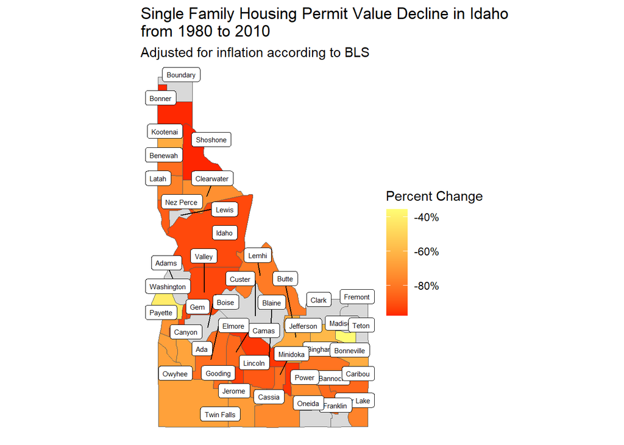

```r
ggplot() +
  geom_sf(data = id_permit_values_adj, aes(geometry = geometry, fill = percent_change)) +
  scale_fill_gradient(low = "#FF2500", high = "#FFFC74", na.value = "grey85", labels = scales::percent_format()) +
  theme_void() +
  geom_label_repel(data = id_permit_values_adj, aes(geometry = geometry, label = CntyName),
                   size = 2, nudge_x = -0.01, nudge_y = 0.2,
                   stat = "sf_coordinates") +
  labs(
    title = "Single Family Housing Permit Value Decline in Idaho \nfrom 1980 to 2010",
    subtitle = "Adjusted for inflation according to BLS",
    fill = "Percent Change"
  ) +
  coord_sf(crs = "NAD27")
```

**Data**

```r
datatable(id_permit_values_adj)
```

|  | CntyName | 1980 | 2010 | 1980_adj | percent_change | FIPS.county | geometry |
| --- | --- | --- | --- | --- | --- | --- | --- |
| 1 | Ada | 1349 | 1273 | 3756.965 | -0.6611626672061092 | 1 | {'type': 'MultiPolygon', 'coordinates': [[[[-116.5115880057035, 43.80735426518536], [-116.280722978803, 43.80707330460079], [-116.1215186007331, 43.69139021974198], [-115.9793975483341, 43.58593826241… |
| 2 | Adams | 4 | 13 | 11.14 |  | 3 | {'type': 'MultiPolygon', 'coordinates': [[[[-116.6906586697153, 45.2680018772429], [-116.3418606924111, 45.26819038599522], [-116.3311483025291, 45.25113620244471], [-116.3033870759398, 45.19276171341… |
| 3 | Bannock | 299 | 137 | 832.715 | -0.8354779246200681 | 5 | {'type': 'MultiPolygon', 'coordinates': [[[[-112.0622313256804, 43.02246174033965], [-112.1261304346611, 42.94459260601449], [-112.128259384215, 42.94046664665505], [-112.1399445568026, 42.90409441935… |
| 4 | Bear Lake | 41 | 27 | 114.185 | -0.7635416210535535 | 7 | {'type': 'MultiPolygon', 'coordinates': [[[[-111.0454631451597, 42.51331405202256], [-111.0459096612396, 42.00164895696135], [-111.506470624102, 41.99960312914977], [-111.5936487248984, 42.09363459836… |
| 5 | Benewah | 40 | 19 | 111.4 | -0.829443447037702 | 9 | {'type': 'MultiPolygon', 'coordinates': [[[[-117.0388058465444, 47.36616505092346], [-116.8997882333163, 47.36632175862786], [-116.6280326248002, 47.37813726916309], [-116.6209883832555, 47.4004241791… |
| 6 | Bingham | 104 | 55 | 289.64 | -0.810109100952907 | 11 | {'type': 'MultiPolygon', 'coordinates': [[[[-112.5190988691605, 43.62666535664337], [-112.5191807234387, 43.42520299234569], [-112.1024466527195, 43.42492392530743], [-111.8217702013417, 43.3662224961… |
| 7 | Blaine | 177 | 24 | 492.9450000000001 | -0.9513130268082646 | 13 | {'type': 'MultiPolygon', 'coordinates': [[[[-114.9703316958591, 43.93826033904972], [-114.9305434061447, 43.96852019239635], [-114.9202606307728, 43.97449109634876], [-114.8866264337312, 43.9892299400… |
| 8 | Boise |  | 24 |  |  | 15 | {'type': 'MultiPolygon', 'coordinates': [[[[-115.2935194073624, 44.33954223494651], [-115.2309189087592, 44.30612056655855], [-115.025274580517, 44.15854504288806], [-115.0164100580567, 44.14305987883… |
| 9 | Bonner | 209 | 17 | 582.065 | -0.9707936398855798 | 17 | {'type': 'MultiPolygon', 'coordinates': [[[[-117.032095804703, 48.84670761122111], [-116.7840674589684, 48.84757684066201], [-116.7824911846523, 48.67426039446655], [-116.783776828399, 48.500766939383… |
| 10 | Bonneville | 237 | 245 | 660.0450000000001 | -0.6288131869796757 | 19 | {'type': 'MultiPolygon', 'coordinates': [[[[-111.62561978402, 43.62684685573744], [-111.3991039618207, 43.62211218719045], [-111.2430768930907, 43.62178911648943], [-111.2253246094657, 43.606457857297… |

[output cut: 34 more lines]

## Additional Critical Factors

Beyond permit values, other critical factors and indicators to consider when analyzing the mortgage crisis include (but aren’t limited to):

- foreclosure rates
- loan prices over time
- housing supply
- credit conditions